# Data Analysis

27/04/2023

## Introduction

In this paper, the military spending on a nation’s or residents’ economic well being has been investigated with the help of attractive as well as interactive visualization tools, like R studio. The paper also demonstrates several data visualizations built with the computer language R and the ggplot2 package, such as choropleth maps, bar plots, scatter plots, time series graphics, and line charts. These graphical visualizations are also intended in order to aid in the discovery of patterns and disparities in GDP per capita, population trends, and life expectancy across countries and across time. These visualizations’ insights can assist organizations like UNICEF identify key areas for intervention and measure progress towards their goals. The United Nations Children’s Fund (UNICEF) created a database that provides the details about the worldwide military spending through specific countries over the years. With the help of this data visualization, organizations can easily understand the current status as well as awareness about worldwide military spending.

```r
library(readr)
library(tidyverse)
```

```r
library(ggplot2)
library(psych)
library(maps)
library(mapdata)
library(mapproj)
library(dplyr)
library(tidyr)
```

### Dataset Load

```r
unicef_metadata <- read.csv("D:/Dataset/unicef_metadata.csv")
```

```r
head(unicef_metadata)
```

```
##       country alpha_2_code alpha_3_code numeric_code iso3c year
## 1 Afghanistan           AF          AFG            4   AFG 1960
## 2 Afghanistan           AF          AFG            4   AFG 1961
## 3 Afghanistan           AF          AFG            4   AFG 1962
## 4 Afghanistan           AF          AFG            4   AFG 1963
## 5 Afghanistan           AF          AFG            4   AFG 1964
## 6 Afghanistan           AF          AFG            4   AFG 1965
##   Population..total GDP.per.capita..constant.2015.US.. GNI..current.US..
## 1           8622466                                 NA         548888849
## 2           8790140                                 NA         560000022
## 3           8969047                                 NA         557777807
## 4           9157465                                 NA         766666707
## 5           9355514                                 NA         815555562
## 6           9565147                                 NA        1026666678
##   Inflation..consumer.prices..annual... Life.expectancy.at.birth..total..years.
## 1                                    NA                                  32.535
## 2                                    NA                                  33.068
## 3                                    NA                                  33.547
## 4                                    NA                                  34.016
## 5                                    NA                                  34.494
## 6                                    NA                                  34.953
##   Military.expenditure....of.GDP.
## 1                              NA
## 2                              NA
## 3                              NA
## 4                              NA
## 5                              NA
## 6                              NA
```

## Data Preprocessing Steps perfomed here

```r
str(unicef_metadata)
```

```
## 'data.frame':    13764 obs. of  12 variables:
##  $ country                                : chr  "Afghanistan" "Afghanistan" "Afghanistan" "Afghanistan" ...
##  $ alpha_2_code                           : chr  "AF" "AF" "AF" "AF" ...
##  $ alpha_3_code                           : chr  "AFG" "AFG" "AFG" "AFG" ...
##  $ numeric_code                           : int  4 4 4 4 4 4 4 4 4 4 ...
##  $ iso3c                                  : chr  "AFG" "AFG" "AFG" "AFG" ...
##  $ year                                   : int  1960 1961 1962 1963 1964 1965 1966 1967 1968 1969 ...
##  $ Population..total                      : int  8622466 8790140 8969047 9157465 9355514 9565147 9783147 10010030 10247780 10494489 ...
##  $ GDP.per.capita..constant.2015.US..     : num  NA NA NA NA NA NA NA NA NA NA ...
##  $ GNI..current.US..                      : num  5.49e+08 5.60e+08 5.58e+08 7.67e+08 8.16e+08 ...
##  $ Inflation..consumer.prices..annual...  : num  NA NA NA NA NA NA NA NA NA NA ...
##  $ Life.expectancy.at.birth..total..years.: num  32.5 33.1 33.5 34 34.5 ...
##  $ Military.expenditure....of.GDP.        : num  NA NA NA NA NA NA NA NA NA NA ...
```

```r
names(unicef_metadata)
```

```
##  [1] "country"
##  [2] "alpha_2_code"
##  [3] "alpha_3_code"
##  [4] "numeric_code"
##  [5] "iso3c"
##  [6] "year"
##  [7] "Population..total"
##  [8] "GDP.per.capita..constant.2015.US.."
##  [9] "GNI..current.US.."
## [10] "Inflation..consumer.prices..annual..."
## [11] "Life.expectancy.at.birth..total..years."
## [12] "Military.expenditure....of.GDP."
```

```r
summary(unicef_metadata)
```

```
##    country          alpha_2_code       alpha_3_code        numeric_code
##  Length:13764       Length:13764       Length:13764       Min.   :  4.0
##  Class :character   Class :character   Class :character   1st Qu.:212.0
##  Mode  :character   Mode  :character   Mode  :character   Median :427.0
##                                                           Mean   :431.1
##                                                           3rd Qu.:659.0
##                                                           Max.   :894.0
##
##     iso3c                year      Population..total
##  Length:13764       Min.   :1960   Min.   :4.582e+03
##  Class :character   1st Qu.:1975   1st Qu.:5.541e+05
##  Mode  :character   Median :1990   Median :4.569e+06
##                     Mean   :1990   Mean   :2.562e+07
##                     3rd Qu.:2006   3rd Qu.:1.538e+07
##                     Max.   :2021   Max.   :1.412e+09
##                                    NA's   :30
##  GDP.per.capita..constant.2015.US.. GNI..current.US..
##  Min.   :   144                     Min.   :9.123e+06
##  1st Qu.:  1363                     1st Qu.:1.508e+09
##  Median :  3711                     Median :8.726e+09
##  Mean   : 11662                     Mean   :1.960e+11
##  3rd Qu.: 13989                     3rd Qu.:5.790e+10
##  Max.   :204190                     Max.   :2.362e+13
##  NA's   :3482                       NA's   :3726
##  Inflation..consumer.prices..annual... Life.expectancy.at.birth..total..years.
##  Min.   :  -17.640                     Min.   :11.99
##  1st Qu.:    2.087                     1st Qu.:57.02
##  Median :    4.753                     Median :67.32
##  Mean   :   24.684                     Mean   :64.43
##  3rd Qu.:   10.183                     3rd Qu.:72.81
##  Max.   :23773.132                     Max.   :85.39
##  NA's   :4951                          NA's   :1079
##  Military.expenditure....of.GDP.
##  Min.   :  0.000
##  1st Qu.:  1.242
##  Median :  1.938
##  Mean   :  2.756
##  3rd Qu.:  3.209
##  Max.   :117.350
##  NA's   :5984
```

```r
sum(is.na(unicef_metadata))
```

```
## [1] 19252
```

```r
unicef_metadata_data <- na.omit(unicef_metadata)
```

```r
sum(is.na(unicef_metadata_data))
```

```
## [1] 0
```

```r
# Compute descriptive statistics for each column
desc <- describe(unicef_metadata_data)

# Display the descriptive statistics in a table format
print(desc, row.names=FALSE)
```

```
##                                         vars    n         mean           sd
## country*                                   1 6132 8.003000e+01 4.588000e+01
## alpha_2_code*                              2 6132 7.615000e+01 4.341000e+01
## alpha_3_code*                              3 6132 7.609000e+01 4.344000e+01
## numeric_code                               4 6132 4.192000e+02 2.473500e+02
## iso3c*                                     5 6132 7.609000e+01 4.344000e+01
## year                                       6 6132 1.996920e+03 1.601000e+01
## Population..total                          7 6132 4.319035e+07 1.352798e+08
## GDP.per.capita..constant.2015.US..         8 6132 1.097603e+04 1.554476e+04
## GNI..current.US..                          9 6132 2.923245e+11 1.230585e+12
## Inflation..consumer.prices..annual...     10 6132 2.265000e+01 2.671200e+02
## Life.expectancy.at.birth..total..years.   11 6132 6.648000e+01 1.041000e+01
## Military.expenditure....of.GDP.           12 6132 2.420000e+00 2.020000e+00
##                                               median      trimmed          mad
## country*                                7.800000e+01 7.984000e+01 5.782000e+01
## alpha_2_code*                           7.600000e+01 7.568000e+01 5.486000e+01
## alpha_3_code*                           7.600000e+01 7.564000e+01 5.486000e+01
## numeric_code                            4.100000e+02 4.152900e+02 2.994900e+02
## iso3c*                                  7.600000e+01 7.564000e+01 5.486000e+01
## year                                    2.000000e+03 1.998010e+03 1.779000e+01
## Population..total                       1.042038e+07 1.878207e+07 1.238838e+07
## GDP.per.capita..constant.2015.US..      3.886550e+03 7.676710e+03 4.665250e+03
## GNI..current.US..                       2.059551e+10 7.036880e+10 2.821447e+10
## Inflation..consumer.prices..annual...   4.870000e+00 6.160000e+00 5.060000e+00
## Life.expectancy.at.birth..total..years. 6.918000e+01 6.720000e+01 1.036000e+01
## Military.expenditure....of.GDP.         1.840000e+00 2.090000e+00 1.190000e+00
##                                                 min          max        range
## country*                                       1.00 1.630000e+02 1.620000e+02
## alpha_2_code*                                  1.00 1.550000e+02 1.540000e+02
## alpha_3_code*                                  1.00 1.550000e+02 1.540000e+02
## numeric_code                                   4.00 8.940000e+02 8.900000e+02
## iso3c*                                         1.00 1.550000e+02 1.540000e+02
## year                                        1960.00 2.020000e+03 6.000000e+01
## Population..total                          65244.00 1.411100e+09 1.411035e+09
## GDP.per.capita..constant.2015.US..           144.03 1.124179e+05 1.122739e+05
## GNI..current.US..                       92353432.53 2.176454e+13 2.176444e+13
## Inflation..consumer.prices..annual...        -13.06 1.174964e+04 1.176270e+04
## Life.expectancy.at.birth..total..years.       25.61 8.462000e+01 5.900000e+01
## Military.expenditure....of.GDP.                0.01 3.179000e+01 3.178000e+01
##                                          skew kurtosis           se
## country*                                 0.03    -1.19 5.900000e-01
## alpha_2_code*                            0.06    -1.18 5.500000e-01
## alpha_3_code*                            0.06    -1.18 5.500000e-01
## numeric_code                             0.10    -1.12 3.160000e+00
## iso3c*                                   0.06    -1.18 5.500000e-01
## year                                    -0.49    -0.78 2.000000e-01
## Population..total                        7.55    62.89 1.727555e+06
## GDP.per.capita..constant.2015.US..       2.33     6.84 1.985100e+02
## GNI..current.US..                       10.14   128.23 1.571486e+10
## Inflation..consumer.prices..annual...   33.82  1343.79 3.410000e+00
## Life.expectancy.at.birth..total..years. -0.58    -0.53 1.300000e-01
## Military.expenditure....of.GDP.          3.01    17.58 3.000000e-02
```

## Interactive Visualization story

The problem that the corporation wants to bring to light is the effect of *military spending* on the economic health of a nation or citizens. The expenditure on defense has a direct influence on the progress of a nation, as the goal of this representation aims to highlight how this effect varies by nation along with population.

## World Map Chart

[figure not shown]

```r
# Group the data by country and select the latest year data
unicef_data_latest <- unicef_metadata_data %>%
  group_by(country) %>%
  filter(year == max(year))

# Here, data has been merged with the world map
map_data <- map_data("world")
worldmerged_data <- merge(map_data, unicef_data_latest, by.x = "region", by.y = "country")

# Plotting the world-map
map <- ggplot(worldmerged_data, aes(x = long, y = lat, group = group, fill = GDP.per.capita..constant.2015.US..)) +
  geom_polygon() +
  scale_fill_gradient(low = "white", high = "red", na.value = "grey50") +
  labs(title = "GDP per capita in 2015 (constant USD)", fill = "GDP per capita") +
  theme_void()
map
```

# Bar chart of GDP per capita via country

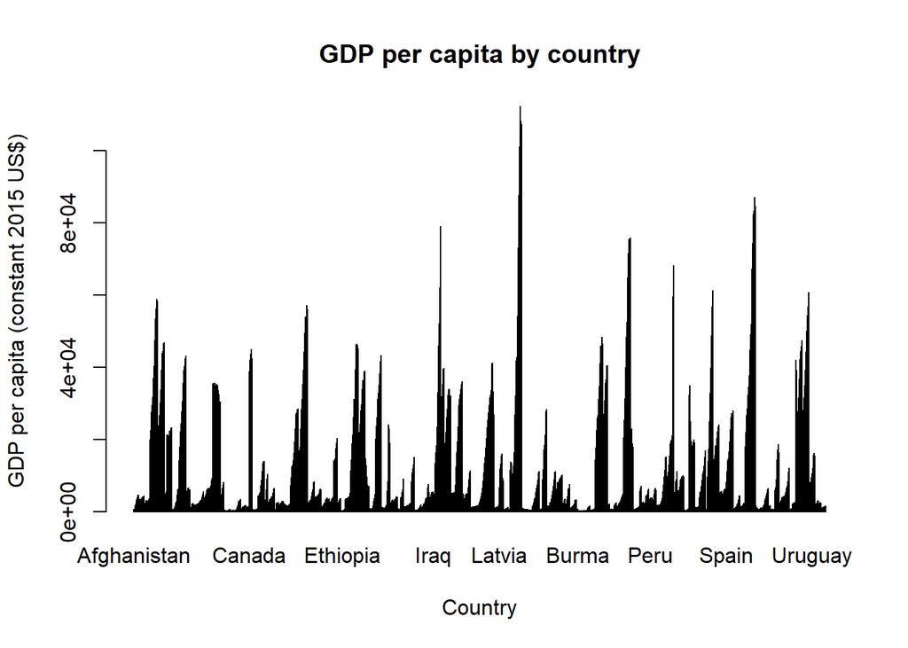

```r
barplot(unicef_metadata_data$GDP.per.capita..constant.2015.US..,
        names.arg = unicef_metadata_data$country,
        main = "GDP per capita by country",
        xlab = "Country",
        ylab = "GDP per capita (constant 2015 US$)")
```

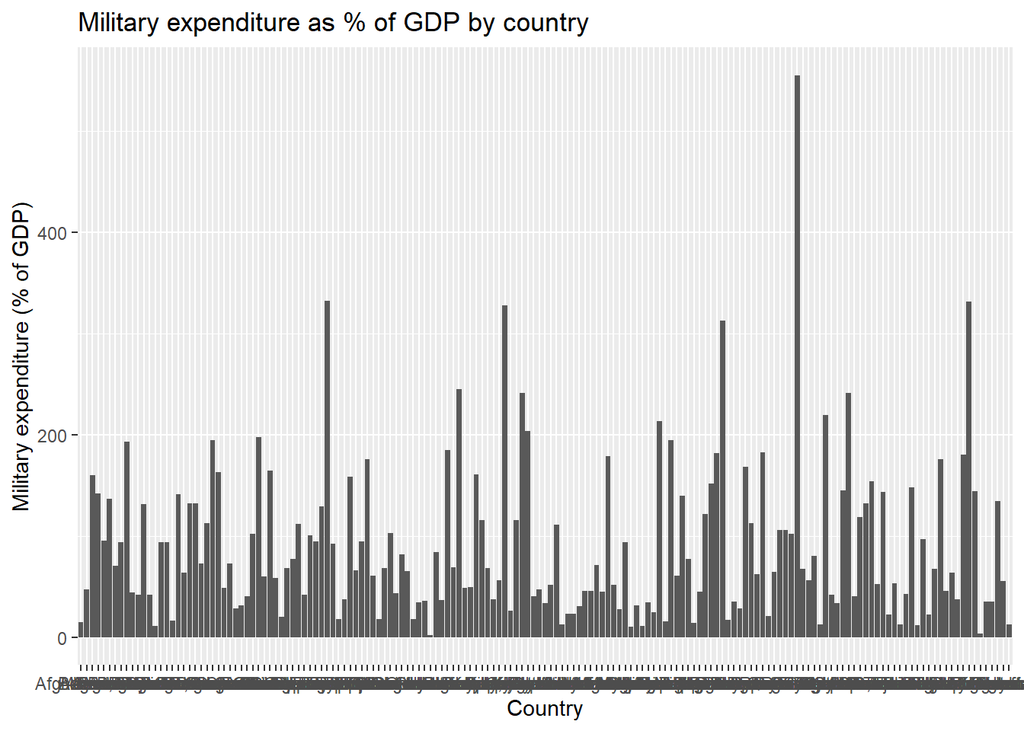

```r
ggplot(unicef_metadata_data, aes(x = country, y = Military.expenditure....of.GDP.)) +
  geom_bar(stat = "identity") +
  labs(title = "Military expenditure as % of GDP by country",
       x = "Country",
       y = "Military expenditure (% of GDP)")
```

### Scatter Plot with linear Line

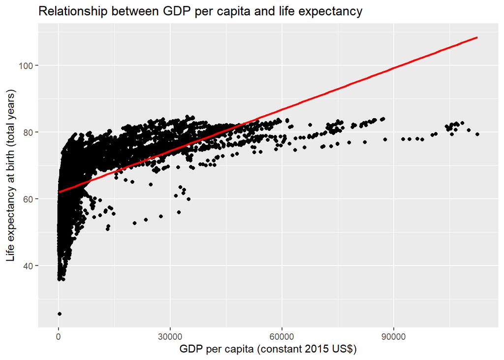

```r
ggplot(data = unicef_metadata_data, aes(x = GDP.per.capita..constant.2015.US.., y = Life.expectancy.at.birth..total..years.)) +
  geom_point() +
  geom_smooth(method = "lm", se = FALSE, color = "red") +
  labs(x = "GDP per capita (constant 2015 US$)", y = "Life expectancy at birth (total years)", title = "Relationship between GDP per capita and life expectancy")
```

> The code is employed to generate a scatter plot using a linear regression line connecting two variables, which are GDP per capita (constant 2015 US dollars) as well as life expectancy at birth (total years).

The scatter plot using the regression line can assist the UNICEF organization in identifying the association among GDP per capita as well as life expectancy, which may prove valuable for a variety of reasons. It also identifies which nations have the greatest and poorest life expectancy and GDP, as well as any patterns or trends. Aside from that, it can track developments in life expectancy and GDP over time as well as identify nations that are trailing or making progress. In general, the scatter plot may help UNICEF make based on data choices and actions that support improved well-being and growth in the economy.

## Time Series plot

[figure not shown]

```r
# Convert year column to date format
unicef_metadata_data$year <- as.Date(paste0(unicef_metadata_data$year, "-01-01"))
# Create a line chart with year and GDP per capita
ggplot(unicef_metadata_data, aes(x = year, y = GDP.per.capita..constant.2015.US.., color = country)) +
  geom_line() +
  labs(title = "GDP per Capita between  Time",
       x = "Year",
       y = "GDP per Capita (constant 2015 US$)",
       color = "Country")
```

The code has been written in R and employs the ggplot2 tool to generate a line chart depicting GDP per capita for various nations through time. The first section of code changes the “year” column from a character or integer type to a date format in the “unicef_metadata_data” data frame. It does this by concatenating “-01-01” to the final portion of each year by employing the “as.Date” function and the “paste0” method. This constructs a date object with the month as well as the day constantly set to January 1st of the provided year (Wickham et al. 2019). This sort of graphic might be beneficial for recognising how GDP per capita in different nations has evolved over time, which could assist guide policies linked to financial growth, reducing poverty, along with social welfare programmes.

[figure not shown]

```r
# Create the time series plot
ggplot(data = unicef_metadata_data, aes(x = year, y = Population..total, group = country, color = country)) +
  geom_line() +
  labs(title = "Total Population Over Time",
       x = "Year",
       y = "Total Population",
       color = "Country") +
  theme_bw()
```

The programmes above are employed to generate a time series graphic in the programming language of R using the ggplot2 package. The graph depicts the total population of various nations throughout time. On the other hand, time series plots like this one may be valuable for spotting recurring patterns and trends regarding population data, which can help guide decisions about resource allocation, programme planning, and policy creation. UNICEF may acquire insights into whether nations are experiencing population increase, decrease, or stagnation by visualizing population changes through time, and build plans to meet the needs of these people.

## Line chart of population over time for a specific country

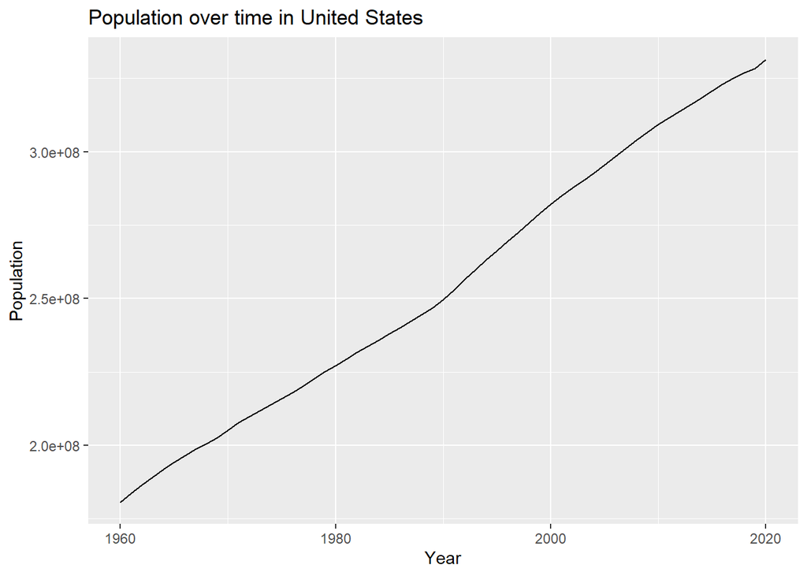

```r
country <- "United States"
data_filtered <- unicef_metadata_data[unicef_metadata_data$country == country,]

ggplot(data_filtered, aes(x = year, y = Population..total)) +
  geom_line() +
  labs(title = paste0("Population over time in ", country),
       x = "Year",
       y = "Population")
```

This code helps to generate a line graph depicting the population trends over the years in the nation indicated by the variable “country” (in this example, “United States”). The population statistics may be used to assist UNICEF in understanding demographic changes in a particular nation and how they may influence the organization’s activities. For example, if the population is rapidly rising, UNICEF may need to change its ways of providing medical care, education, and various other services to suit the requirements of additional people (Dibia and Demiralp, 2019). The chart could additionally be utilized for sending this information to parties like politicians and supporters, helping them to make more informed choices.

## Conclusion

In the end, the interactive visualization story created around the impact of military expenditure on a nation’s or residents’ financial condition gives significant information to the UNICEF organization to use in making educated decisions regarding the allocation of resources, policy development, or programme planning. The story provides a complete view of GDP per capita, life expectancy, population trends, and their interrelationships across numerous nations utilizing data visualization approaches such as choropleth maps, bar plots, scatter plots, line charts, as well as time series graphs. Further, these visualization approaches aid in spotting trends and anomalies in economic data, following changes over time as well as highlighting problem areas.

## References Lists

Patil, I., 2021. Visualizations with statistical details: The’ggstatsplot’approach. Journal of Open Source Software, 6(61), p.3167.

Kaya, E., Agca, M., Adiguzel, F. and Cetin, M., 2019. Spatial data analysis with R programming for environment. Human and ecological risk assessment: An International Journal, 25(6), pp.1521-1530.

Wickham, H., Averick, M., Bryan, J., Chang, W., McGowan, L.D.A., François, R., Grolemund, G., Hayes, A., Henry, L., Hester, J. and Kuhn, M., 2019. Welcome to the Tidyverse. Journal of open source software, 4(43), p.1686.

Dibia, V. and Demiralp, Ç., 2019. Data2vis: Automatic generation of data visualizations using sequence-to-sequence recurrent neural networks. IEEE computer graphics and applications, 39(5), pp.33-46.